# Week 13 HLT

# is there a difference in the body mass of the penguins

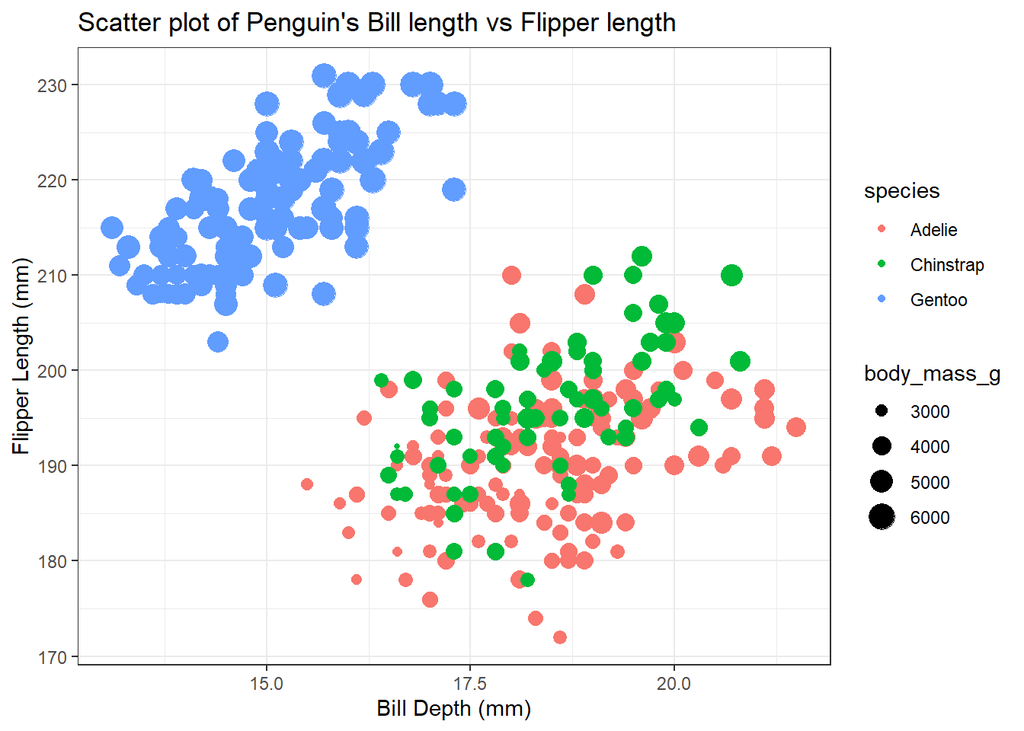

```r
penguins %>%
  ggplot(aes(bill_depth_mm, flipper_length_mm, col = species, size = body_mass_g))+
  geom_point()+
  ggtitle("Scatter plot of Penguin's Bill length vs Flipper length")+
  xlab("Bill Depth (mm)")+
  ylab("Flipper Length (mm)")+
  theme_bw()
```

```r
# graph shows that gentor penguins larger body mass
```

# Map by island and body mass

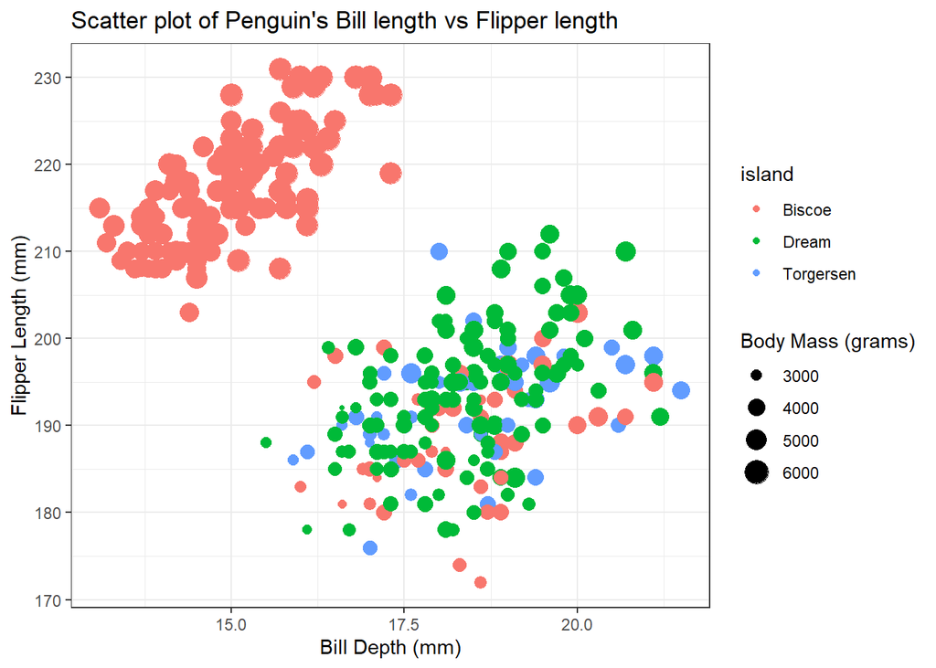

```r
penguins %>%
  ggplot(aes(bill_depth_mm, flipper_length_mm, col = island, size = body_mass_g))+
  geom_point()+
  ggtitle("Scatter plot of Penguin's Bill length vs Flipper length")+
  xlab("Bill Depth (mm)")+
  ylab("Flipper Length (mm)")+
  theme_bw()+
  labs(size = "Body Mass (grams)")
```

```r
# graph shows that  penguins that lives in Biscoe islands have larger body mass
```

# Is there a difference in size of the body mass by gender

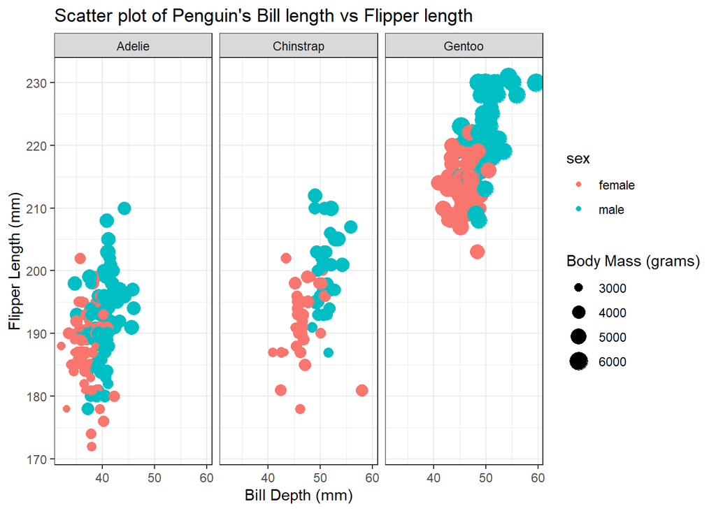

```r
penguins %>%
  ggplot(aes(bill_length_mm, flipper_length_mm, col = sex, size = body_mass_g))+
  geom_point()+
  ggtitle("Scatter plot of Penguin's Bill length vs Flipper length")+
  xlab("Bill Depth (mm)")+
  ylab("Flipper Length (mm)")+
  theme_bw()+
  facet_wrap(~species)+
  labs(size = "Body Mass (grams)")
```

```r
# Appears that male penguins are larger
```

# lets build a classification model to predict the gender of the penguins

```r
# drop column year- wont be used for our modelling

penguins = penguins %>% select(-year)

# import tidymodel library (for machine learning)
library(tidymodels)
# split dataset into training and testing set
set.seed(100) # ensures reproducibility
penguins_split = initial_split(penguins, prop = 0.75, strata = sex)
penguins_train = training(penguins_split)
penguins_test = testing(penguins_split)
```

# Create 10 K fold resampling

```r
set.seed(100)
kfolds = vfold_cv(penguins_train, v = 10)
kfolds
```

```
## #  10-fold cross-validation
## # A tibble: 10 x 2
##    splits           id
##    <list>           <chr>
##  1 <split [224/25]> Fold01
##  2 <split [224/25]> Fold02
##  3 <split [224/25]> Fold03
##  4 <split [224/25]> Fold04
##  5 <split [224/25]> Fold05
##  6 <split [224/25]> Fold06
##  7 <split [224/25]> Fold07
##  8 <split [224/25]> Fold08
##  9 <split [224/25]> Fold09
## 10 <split [225/24]> Fold10
```

# Lets compare two models: A simple Logistic Regression and Random Forest model using Todymodel workflow

Step 1: Specify the models

```r
# logistic reg
glm_spec = logistic_reg() %>%
  set_mode("classification") %>%
  set_engine("glm")

# Random Forest Model
rand_spec = rand_forest() %>%
  set_mode("classification") %>%
  set_engine("ranger")
```

# Step 2: Set workflow pipeline

```r
penguins_wf = workflow() %>%
  add_formula(sex~.) # we will model sex against all other variables
```

# Step 3: Fit the Models against each of the resamples

Fit Logistic model

```r
glm_fit = penguins_wf %>%
  add_model(glm_spec) %>%
  fit_resamples(
    resamples = kfolds,
    control = control_resamples(save_pred = TRUE)
  )
glm_fit
```

```
## # Resampling results
## # 10-fold cross-validation
## # A tibble: 10 x 5
##    splits           id     .metrics         .notes           .predictions
##    <list>           <chr>  <list>           <list>           <list>
##  1 <split [224/25]> Fold01 <tibble [2 x 4]> <tibble [0 x 1]> <tibble [25 x 6]>
##  2 <split [224/25]> Fold02 <tibble [2 x 4]> <tibble [0 x 1]> <tibble [25 x 6]>
##  3 <split [224/25]> Fold03 <tibble [2 x 4]> <tibble [0 x 1]> <tibble [25 x 6]>
##  4 <split [224/25]> Fold04 <tibble [2 x 4]> <tibble [0 x 1]> <tibble [25 x 6]>
##  5 <split [224/25]> Fold05 <tibble [2 x 4]> <tibble [0 x 1]> <tibble [25 x 6]>
##  6 <split [224/25]> Fold06 <tibble [2 x 4]> <tibble [0 x 1]> <tibble [25 x 6]>
##  7 <split [224/25]> Fold07 <tibble [2 x 4]> <tibble [0 x 1]> <tibble [25 x 6]>
##  8 <split [224/25]> Fold08 <tibble [2 x 4]> <tibble [0 x 1]> <tibble [25 x 6]>
##  9 <split [224/25]> Fold09 <tibble [2 x 4]> <tibble [0 x 1]> <tibble [25 x 6]>
## 10 <split [225/24]> Fold10 <tibble [2 x 4]> <tibble [0 x 1]> <tibble [24 x 6]>
```

Fit Random Forest model

```r
rand_fit = penguins_wf %>%
  add_model(rand_spec) %>%
  fit_resamples(
    resamples = kfolds,
    control = control_resamples(save_pred = TRUE)
  )
rand_fit
```

```
## # Resampling results
## # 10-fold cross-validation
## # A tibble: 10 x 5
##    splits           id     .metrics         .notes           .predictions
##    <list>           <chr>  <list>           <list>           <list>
##  1 <split [224/25]> Fold01 <tibble [2 x 4]> <tibble [0 x 1]> <tibble [25 x 6]>
##  2 <split [224/25]> Fold02 <tibble [2 x 4]> <tibble [0 x 1]> <tibble [25 x 6]>
##  3 <split [224/25]> Fold03 <tibble [2 x 4]> <tibble [0 x 1]> <tibble [25 x 6]>
##  4 <split [224/25]> Fold04 <tibble [2 x 4]> <tibble [0 x 1]> <tibble [25 x 6]>
##  5 <split [224/25]> Fold05 <tibble [2 x 4]> <tibble [0 x 1]> <tibble [25 x 6]>
##  6 <split [224/25]> Fold06 <tibble [2 x 4]> <tibble [0 x 1]> <tibble [25 x 6]>
##  7 <split [224/25]> Fold07 <tibble [2 x 4]> <tibble [0 x 1]> <tibble [25 x 6]>
##  8 <split [224/25]> Fold08 <tibble [2 x 4]> <tibble [0 x 1]> <tibble [25 x 6]>
##  9 <split [224/25]> Fold09 <tibble [2 x 4]> <tibble [0 x 1]> <tibble [25 x 6]>
## 10 <split [225/24]> Fold10 <tibble [2 x 4]> <tibble [0 x 1]> <tibble [24 x 6]>
```

# Evaluate the results

```r
# Performance metrics of Logistic model
glm_fit %>% collect_metrics() # 92% Training Accuracy
```

```
## # A tibble: 2 x 6
##   .metric  .estimator  mean     n std_err .config
##   <chr>    <chr>      <dbl> <int>   <dbl> <chr>
## 1 accuracy binary     0.920    10 0.0133  Preprocessor1_Model1
## 2 roc_auc  binary     0.981    10 0.00574 Preprocessor1_Model1
```

```r
# Performance metrics of Random Forest model
rand_fit %>% collect_metrics() # 92% Training Accuracy
```

```
## # A tibble: 2 x 6
##   .metric  .estimator  mean     n std_err .config
##   <chr>    <chr>      <dbl> <int>   <dbl> <chr>
## 1 accuracy binary     0.920    10 0.0169  Preprocessor1_Model1
## 2 roc_auc  binary     0.972    10 0.00953 Preprocessor1_Model1
```

# Both models have similar accuracy. Folowing Ocam Razor Principle, we will pick the logistic model which is simpler and more explainable. We will fit on the training data and evaluate on the testing data using last_fit

```r
penguins_final = penguins_wf %>%
  add_model(glm_spec) %>%
  last_fit(penguins_split)
penguins_final
```

```
## # Resampling results
## # Manual resampling
## # A tibble: 1 x 6
##   splits           id               .metrics   .notes    .predictions  .workflow
##   <list>           <chr>            <list>     <list>    <list>        <list>
## 1 <split [249/84]> train/test split <tibble [~ <tibble ~ <tibble [84 ~ <workflo~
```

```r
penguins_final %>% collect_metrics()
```

```
## # A tibble: 2 x 4
##   .metric  .estimator .estimate .config
##   <chr>    <chr>          <dbl> <chr>
## 1 accuracy binary         0.905 Preprocessor1_Model1
## 2 roc_auc  binary         0.976 Preprocessor1_Model1
```

# The Logistic model has an accuracy of 91% on the test dataset. It is not overfitting

```r
# get the confusion matrix
penguins_final %>%
  collect_predictions() %>%
  conf_mat(sex, .pred_class)
```

```
##           Truth
## Prediction female male
##     female     39    5
##     male        3   37
```

# Lets get the odd ratios of the predictors to see which variables were significant in predicting the gender of the penguins

```r
penguins_final$.workflow[[1]] %>%
  tidy(exponentiate = TRUE)
```

```
## # A tibble: 9 x 5
##   term              estimate std.error statistic      p.value
##   <chr>                <dbl>     <dbl>     <dbl>        <dbl>
## 1 (Intercept)       1.31e-35  14.3        -5.61  0.0000000200
## 2 speciesChinstrap  3.27e- 4   1.99       -4.03  0.0000550
## 3 speciesGentoo     3.14e- 4   2.95       -2.73  0.00631
## 4 islandDream       2.71e+ 0   0.930       1.07  0.284
## 5 islandTorgersen   6.58e- 1   0.996      -0.420 0.674
## 6 bill_length_mm    1.88e+ 0   0.158       3.99  0.0000664
## 7 bill_depth_mm     5.10e+ 0   0.373       4.37  0.0000125
## 8 flipper_length_mm 1.03e+ 0   0.0542      0.463 0.643
## 9 body_mass_g       1.01e+ 0   0.00121     4.70  0.00000259
```

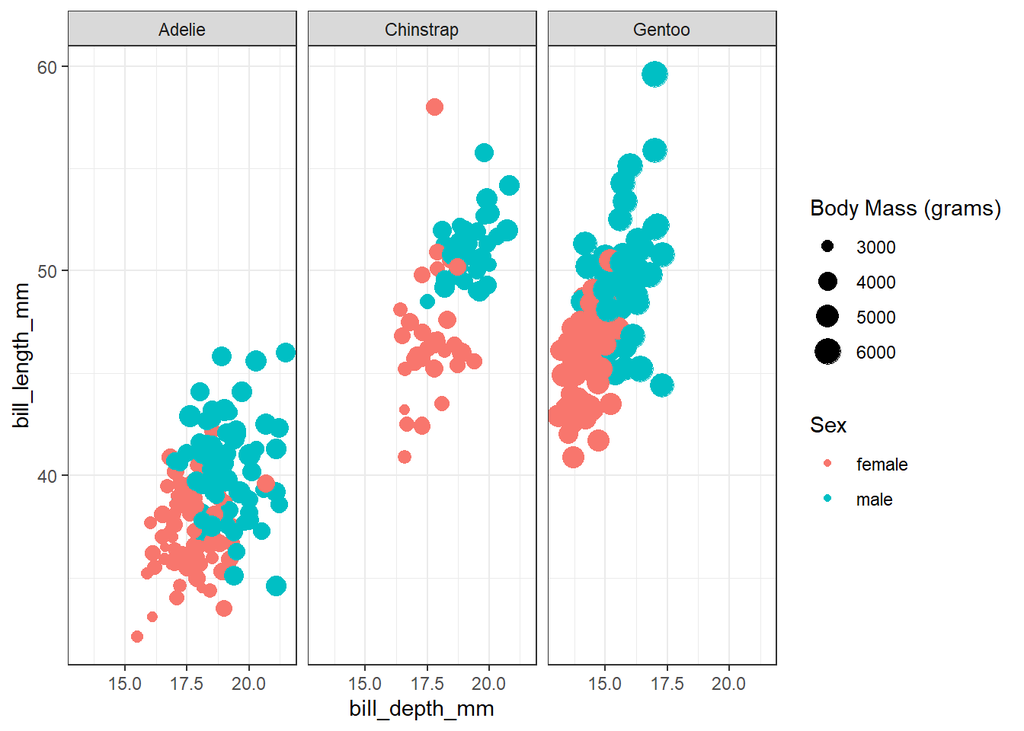

```r
penguins %>%
  ggplot(aes(bill_depth_mm, bill_length_mm, color = sex, size = body_mass_g))+
  geom_point()+
  facet_wrap(~species)+
  labs(color = "Sex", size = "Body Mass (grams)")+
  theme_bw()
```

# Female and male penguins are much more seperated.